# Logistic Regression Project

**A Classification Model that can predict whether or not a person has presence of heart disease based on physical features of that person (age,sex, cholesterol, etc...)**

### Imports

```python
import numpy as np
import pandas as pd
import seaborn as sns
import matplotlib.pyplot as plt
```

### Data

This database contains 14 physical attributes based on physical testing of a patient. Blood samples are taken and the patient also conducts a brief exercise test. The "goal" field refers to the presence of heart disease in the patient. It is integer (0 for no presence, 1 for presence). In general, to confirm 100% if a patient has heart disease can be quite an invasive process, so if we can create a model that accurately predicts the likelihood of heart disease, we can help avoid expensive and invasive procedures.

Content

Attribute Information:

- age
- sex
- chest pain type (4 values)
- resting blood pressure
- serum cholestoral in mg/dl
- fasting blood sugar > 120 mg/dl
- resting electrocardiographic results (values 0,1,2)
- maximum heart rate achieved
- exercise induced angina
- oldpeak = ST depression induced by exercise relative to rest
- the slope of the peak exercise ST segment
- number of major vessels (0-3) colored by flourosopy
- thal: 3 = normal; 6 = fixed defect; 7 = reversable defect
- target:0 for no presence of heart disease, 1 for presence of heart disease

Original Source: https://archive.ics.uci.edu/ml/datasets/Heart+Disease

Creators:

Hungarian Institute of Cardiology. Budapest: Andras Janosi, M.D. University Hospital, Zurich, Switzerland: William Steinbrunn, M.D. University Hospital, Basel, Switzerland: Matthias Pfisterer, M.D. V.A. Medical Center, Long Beach and Cleveland Clinic Foundation: Robert Detrano, M.D., Ph.D.

```python
df = pd.read_csv('../DATA/heart.csv')
df.head()
```

|  | age | sex | cp | trestbps | chol | fbs | restecg | thalach | exang | oldpeak | slope | ca | thal | target |
| --- | --- | --- | --- | --- | --- | --- | --- | --- | --- | --- | --- | --- | --- | --- |
| 0 | 63 | 1 | 3 | 145 | 233 | 1 | 0 | 150 | 0 | 2.3 | 0 | 0 | 1 | 1 |
| 1 | 37 | 1 | 2 | 130 | 250 | 0 | 1 | 187 | 0 | 3.5 | 0 | 0 | 2 | 1 |
| 2 | 41 | 0 | 1 | 130 | 204 | 0 | 0 | 172 | 0 | 1.4 | 2 | 0 | 2 | 1 |
| 3 | 56 | 1 | 1 | 120 | 236 | 0 | 1 | 178 | 0 | 0.8 | 2 | 0 | 2 | 1 |
| 4 | 57 | 0 | 0 | 120 | 354 | 0 | 1 | 163 | 1 | 0.6 | 2 | 0 | 2 | 1 |

```python
df['target'].value_counts()
```

```
target
1    165
0    138
Name: count, dtype: int64
```

### Exploratory Data Analysis and Visualization

```python
df.isnull().sum()
```

```
age         0
sex         0
cp          0
trestbps    0
chol        0
fbs         0
restecg     0
thalach     0
exang       0
oldpeak     0
slope       0
ca          0
thal        0
target      0
dtype: int64
```

```python
df.info()
```

```
<class 'pandas.core.frame.DataFrame'>
RangeIndex: 303 entries, 0 to 302
Data columns (total 14 columns):
 #   Column    Non-Null Count  Dtype
---  ------    --------------  -----
 0   age       303 non-null    int64
 1   sex       303 non-null    int64
 2   cp        303 non-null    int64
 3   trestbps  303 non-null    int64
 4   chol      303 non-null    int64
 5   fbs       303 non-null    int64
 6   restecg   303 non-null    int64
 7   thalach   303 non-null    int64
 8   exang     303 non-null    int64
 9   oldpeak   303 non-null    float64
 10  slope     303 non-null    int64
 11  ca        303 non-null    int64
 12  thal      303 non-null    int64
 13  target    303 non-null    int64
dtypes: float64(1), int64(13)
memory usage: 33.3 KB
```

```python
df.describe().transpose()
```

|  | count | mean | std | min | 25% | 50% | 75% | max |
| --- | --- | --- | --- | --- | --- | --- | --- | --- |
| age | 303.0 | 54.366337 | 9.082101 | 29.0 | 47.5 | 55.0 | 61.0 | 77.0 |
| sex | 303.0 | 0.683168 | 0.466011 | 0.0 | 0.0 | 1.0 | 1.0 | 1.0 |
| cp | 303.0 | 0.966997 | 1.032052 | 0.0 | 0.0 | 1.0 | 2.0 | 3.0 |
| trestbps | 303.0 | 131.623762 | 17.538143 | 94.0 | 120.0 | 130.0 | 140.0 | 200.0 |
| chol | 303.0 | 246.264026 | 51.830751 | 126.0 | 211.0 | 240.0 | 274.5 | 564.0 |
| fbs | 303.0 | 0.148515 | 0.356198 | 0.0 | 0.0 | 0.0 | 0.0 | 1.0 |
| restecg | 303.0 | 0.528053 | 0.525860 | 0.0 | 0.0 | 1.0 | 1.0 | 2.0 |
| thalach | 303.0 | 149.646865 | 22.905161 | 71.0 | 133.5 | 153.0 | 166.0 | 202.0 |
| exang | 303.0 | 0.326733 | 0.469794 | 0.0 | 0.0 | 0.0 | 1.0 | 1.0 |
| oldpeak | 303.0 | 1.039604 | 1.161075 | 0.0 | 0.0 | 0.8 | 1.6 | 6.2 |
| slope | 303.0 | 1.399340 | 0.616226 | 0.0 | 1.0 | 1.0 | 2.0 | 2.0 |
| ca | 303.0 | 0.729373 | 1.022606 | 0.0 | 0.0 | 0.0 | 1.0 | 4.0 |
| thal | 303.0 | 2.313531 | 0.612277 | 0.0 | 2.0 | 2.0 | 3.0 | 3.0 |
| target | 303.0 | 0.544554 | 0.498835 | 0.0 | 0.0 | 1.0 | 1.0 | 1.0 |

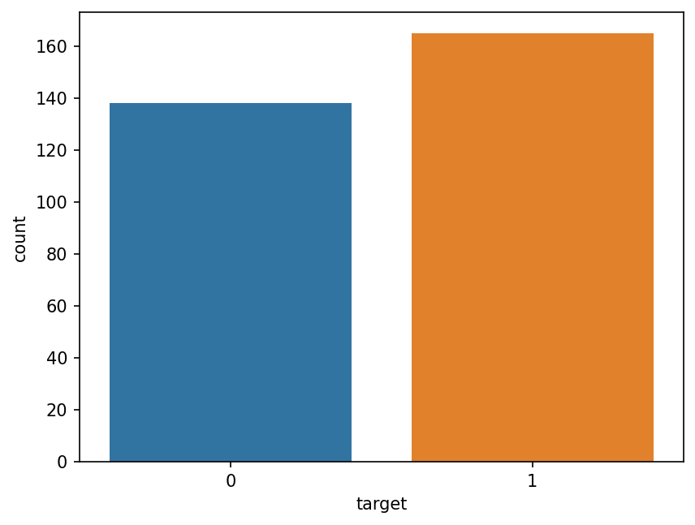

```python
plt.figure(dpi=150)
sns.countplot(data=df, x = 'target');
```

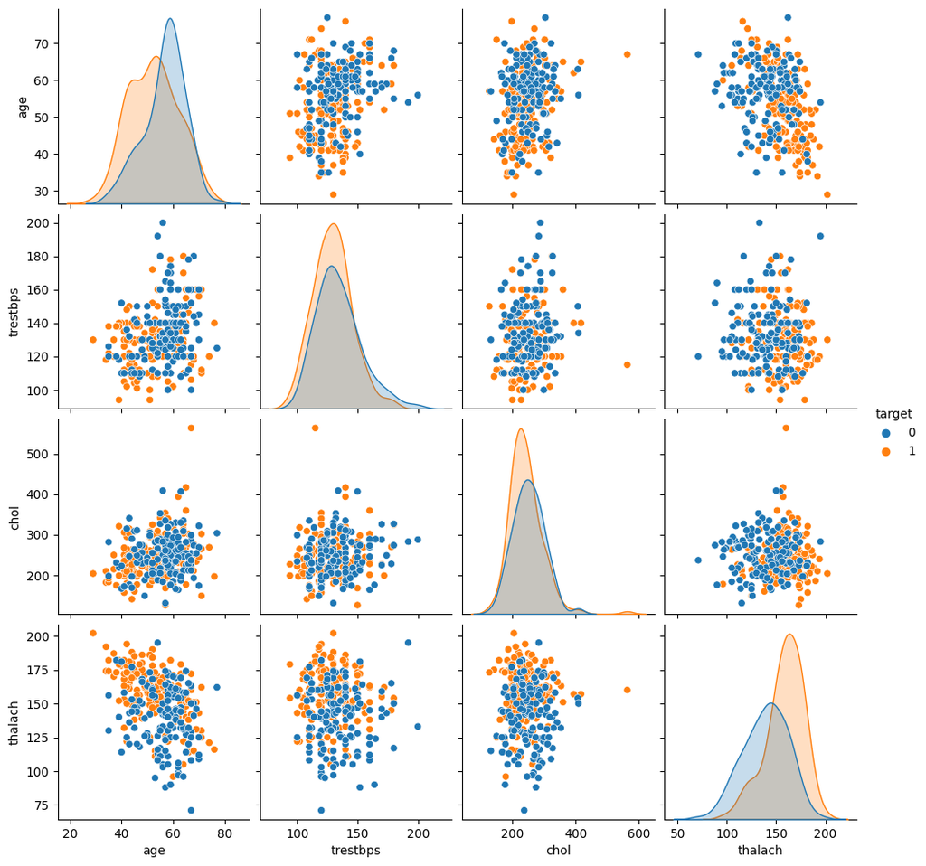

```python
sns.pairplot(data=df[['age','trestbps', 'chol','thalach','target']], hue='target');
```

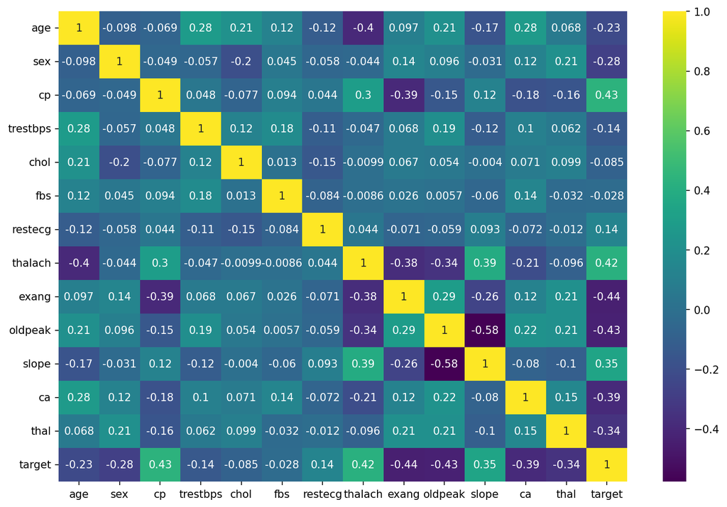

```python
plt.figure(figsize=(12,8), dpi=150)
sns.heatmap(df.corr(numeric_only=True), cmap='viridis', annot=True);
```

## Machine Learning

### Train | Test Split and Scaling

```python
from sklearn.model_selection import train_test_split

X = df.drop('target', axis=1)
y = df['target']

X_train, X_test, y_train, y_test = train_test_split(X,y, test_size=0.10, random_state=101)
```

```python
from sklearn.preprocessing import StandardScaler

scaler = StandardScaler()

scaled_X_train = scaler.fit_transform(X_train)
scaled_X_test = scaler.transform(X_test)
```

### Logistic Regression Model

```python
from sklearn.linear_model import LogisticRegression
log_model = LogisticRegression(max_iter=30000, solver='saga', multi_class='ovr')
```

```python
penalty = ['elasticnet']
c = np.logspace(0,4,10)
l1_ratio = [.1, .5, .7, .9, .95, .99, 1]

parameter_grid = {'penalty': penalty, 'C': c, 'l1_ratio': l1_ratio}
```

```python
from sklearn.model_selection import GridSearchCV
grid_model = GridSearchCV(estimator=log_model,param_grid=parameter_grid)
```

```python
grid_model.fit(scaled_X_train, y_train)
```

```
GridSearchCV(estimator=LogisticRegression(max_iter=30000, multi_class='ovr',
                                          solver='saga'),
             param_grid={'C': array([1.00000000e+00, 2.78255940e+00, 7.74263683e+00, 2.15443469e+01,
       5.99484250e+01, 1.66810054e+02, 4.64158883e+02, 1.29154967e+03,
       3.59381366e+03, 1.00000000e+04]),
                         'l1_ratio': [0.1, 0.5, 0.7, 0.9, 0.95, 0.99, 1],
                         'penalty': ['elasticnet']})
```

```python
grid_model.best_params_
```

```
{'C': 1.0, 'l1_ratio': 0.7, 'penalty': 'elasticnet'}
```

#### Coeffecients

```python
grid_model.best_estimator_.coef_
```

```
array([[-0.0552142 , -0.70830696,  0.8896672 , -0.24615214, -0.19435064,
         0.01568237,  0.10323943,  0.42529809, -0.41447456, -0.52478706,
         0.36508483, -0.83791889, -0.5674356 ]])
```

```python
coef = pd.Series(data = grid_model.best_estimator_.coef_[0], index=X.columns)
coef = coef.sort_values()
coef
```

```
ca         -0.837919
sex        -0.708307
thal       -0.567436
oldpeak    -0.524787
exang      -0.414475
trestbps   -0.246152
chol       -0.194351
age        -0.055214
fbs         0.015682
restecg     0.103239
slope       0.365085
thalach     0.425298
cp          0.889667
dtype: float64
```

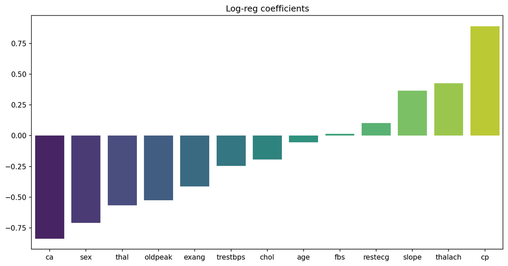

```python
plt.figure(figsize=(12,6), dpi=150)
plt.title('Log-reg coefficients')
sns.barplot(x = coef.index, y = coef.values, palette='viridis');
```

### Model Performance Evaluation

```python
y_pred = grid_model.predict(scaled_X_test)
```

```python
from sklearn.metrics import confusion_matrix, classification_report, ConfusionMatrixDisplay
```

```python
cm = confusion_matrix(y_test, y_pred)
```

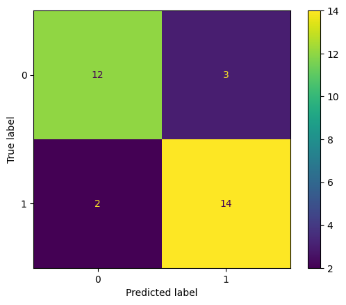

```python
ConfusionMatrixDisplay(cm).plot();
```

```python
cr = classification_report(y_test, y_pred)
print(cr)
```

```
              precision    recall  f1-score   support

           0       0.86      0.80      0.83        15
           1       0.82      0.88      0.85        16

    accuracy                           0.84        31
   macro avg       0.84      0.84      0.84        31
weighted avg       0.84      0.84      0.84        31
```

#### Performance Curves

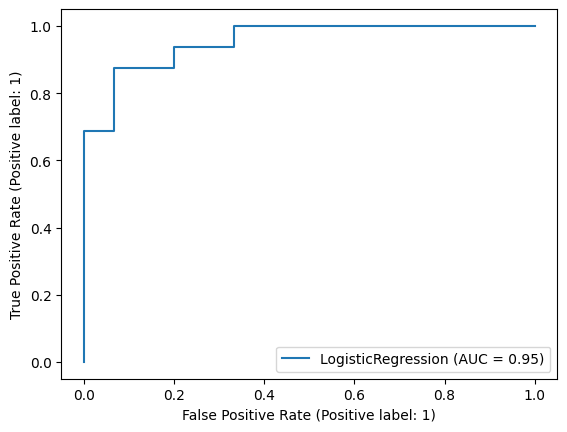

```python
from sklearn.metrics import RocCurveDisplay, PrecisionRecallDisplay

RocCurveDisplay.from_estimator(grid_model.best_estimator_, scaled_X_test, y_test);
```

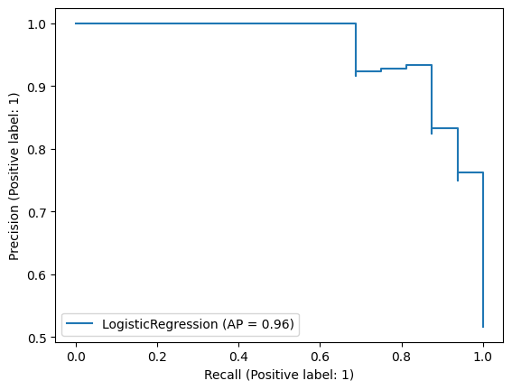

```python
PrecisionRecallDisplay.from_estimator(grid_model.best_estimator_, scaled_X_test, y_test);
```

A patient with the following features has come into the medical office:**

[output not shown]

```python
patient = np.array([[ 54. ,   1. ,   0. , 122. , 286. ,   0. ,   0. , 116. ,   1. ,
          3.2,   1. ,   2. ,   2. ]])
patient = patient.reshape(1, -1)
```

```python
grid_model.predict(patient)
```

```
array([0])
```

```python
grid_model.predict_proba(patient)
```

```
array([[1.0000000e+00, 5.5742403e-20]])
```

A 0, together with a probability of 1 for the 0-group, indicates the patient has very likely no presence of heart disease according to the model.

### Saving the model

```python
from joblib import dump

dump(grid_model, 'Log_Reg_Heart_Disease_Prediction.joblib')
```

```
['Log_Reg_Heart_Disease_Prediction.joblib']
```